# [WUM] Praca domowa nr 1

### Mateusz Polakowski

W pierwszej pracy domowej zadane zostało poeksplorować dane z pierwszego wykładu dotyczące serwisu *Allegro*. Ponieważ jest to praca w języku Python, to z wylistowanych propozycji pakietów dodatkowych do przebadania wybrałem pakiet *lens* [(link do oficjalnego repozytorium)](https://github.com/facultyai/lens). Poniżej zawarłem kilka obserwacji, a także przegląd najciekawszych funkcji pakietu. Ponadto, przy użyciu pakietów *pandas*, *datetime*, czy *matplotlib* przeprocesowałem dane, aby zostawić tylko najciekawsze i gotowe do zaprezentowania.

## Wgranie potrzebnych pakietów

```python
%matplotlib inline
import pandas as pd
import numpy as np
from datetime import datetime
import lens
import matplotlib.pyplot as plt
from matplotlib.dates import date2num
import warnings

warnings.simplefilter('ignore')
pd.set_option('display.float_format', lambda x: '%.2f' % x)
```

## Przygotowanie danych

```python
# Wczytanie danych
allegro = pd.read_csv("allegro-api-transactions.csv").iloc[:, 1:]
allegro_cat = pd.read_csv("allegro-categories-eng.txt", sep="; ", engine="python")
```

```python
# Połączenie powyższych tabel i wyrzucenie kolumn, z których nie będziemy korzystać
allegro = pd.merge(allegro, allegro_cat, on = "main_category", how = "left").drop("main_category", axis=1)
allegro = allegro.drop(["item_id", "categories", "seller",
                        "it_location", "it_quantity", "it_seller_rating"], axis=1)

# Zamiana 0, 1 na ładniejsze oznaczenia "no" oraz "yes"
for i in [1, 2, 4, 5]:
    allegro.iloc[:, i] = pd.Categorical(allegro.iloc[:, i],
                                       categories=[0,1]).rename_categories(["no", "yes"])

# Pre-processing kolumny date, "podłoga" na godzinie daty
allegro.date = allegro.date.apply(lambda time: datetime.strptime(time[:13], '%Y-%m-%d %H'))
```

Poniżej dla przykładu załączam pierwsze wiersze finalnej tabeli *allegro*, na której będziemy w dalszej części sprawozdania działać.

```python
allegro.head()
```

|  | date | pay_option_on_delivery | pay_option_transfer | price | it_is_allegro_standard | it_is_brand_zone | main_category_eng |
| --- | --- | --- | --- | --- | --- | --- | --- |
| 0 | 2016-04-03 21:00:00 | yes | yes | 59.99 | yes | no | Computers |
| 1 | 2016-04-03 15:00:00 | yes | yes | 4.90 | yes | no | Clothing, Shoes, Accessories |
| 2 | 2016-04-03 14:00:00 | yes | yes | 109.90 | yes | no | Home & Garden |
| 3 | 2016-04-03 19:00:00 | yes | yes | 18.50 | no | no | Books and Comics |
| 4 | 2016-04-03 18:00:00 | yes | yes | 19.90 | yes | no | Clothing, Shoes, Accessories |

## Analiza danych oraz eksploracja pakietu *lens*

Na początku zobaczmy, czy da się jakoś podsumować surowe dane które posiadamy. Poniżej znajdują się dwie tabele, które zawierają kolejno najbardziej popularne kategorie wsród kupujących ...

```python
t = allegro.groupby(["main_category_eng"]).size().reset_index()
t.columns = ["main_category", "count"]
t.sort_values(by = ["count"], ascending = False).head(10)
```

|  | main_category | count |
| --- | --- | --- |
| 14 | Home & Garden | 91042 |
| 5 | Clothing, Shoes, Accessories | 54257 |
| 1 | Automotive | 45941 |
| 2 | Babies | 42107 |
| 3 | Beauty | 28096 |
| 24 | Sport & Tourism | 27532 |
| 22 | RTV & AGD | 20341 |
| 20 | Phones & Accessories | 19805 |
| 7 | Computers | 14491 |
| 13 | Health | 13166 |

... i liczby zakupów w zależności od danych jakościowych w tabeli. Jak widać kategoria *brand zone* nie jest popularna w serwisie. Oprócz tego, nie da się znaleźć jakiejkolwiek zależności wśród kategorii. Wartości wydają się być całkowicie losowe (te przypuszczenia potwierdzą kolejne wstawki poniżej.

```python
def color(val):
    if val == 'no':
        color = 'red'
    elif val == 'yes':
        color = 'green'
    else:
        color = 'black'
    return 'color: {0}; font-weight: bold; text-align: center'.format(color)

groups = ["pay_option_on_delivery", "pay_option_transfer", "it_is_allegro_standard", "it_is_brand_zone"]
czy_kor = allegro.groupby(groups).size().reset_index()
czy_kor.columns = groups + ["count"]
czy_kor.sort_values(by = ["count"], ascending = False).style.applymap(color)
```

|  | pay_option_on_delivery | pay_option_transfer | it_is_allegro_standard | it_is_brand_zone | count |
| --- | --- | --- | --- | --- | --- |
| 14 | yes | yes | yes | no | 201866 |
| 12 | yes | yes | no | no | 105841 |
| 8 | yes | no | no | no | 28378 |
| 10 | yes | no | yes | no | 26141 |
| 4 | no | yes | no | no | 20310 |
| 0 | no | no | no | no | 18153 |
| 6 | no | yes | yes | no | 9572 |
| 2 | no | no | yes | no | 2747 |
| 11 | yes | no | yes | yes | 2176 |
| 15 | yes | yes | yes | yes | 2166 |
| 13 | yes | yes | no | yes | 1310 |
| 9 | yes | no | no | yes | 888 |
| 3 | no | no | yes | yes | 231 |
| 7 | no | yes | yes | yes | 164 |
| 1 | no | no | no | yes | 42 |
| 5 | no | yes | no | yes | 35 |

Ponieważ dane pochodzą tylko z jednego dnia, to zobaczmy jak wygląda rozkład wydanych pieniędzy według kolejnych godzin:

```python
# Stworzenie tabeli potrzebnej do wykresu
money_flow_by_hour = allegro.groupby("date")["price"].agg(sum).reset_index()
money_flow_by_hour.date = date2num(money_flow_by_hour.date)
```

```python
# Funkcja pomocnicza
def concat(a, b):
    """Funkcja laczy dwa wektory po elementach"""
    if len(a) != len(b):
        raise Exception("Invalid length")
    x = []
    for i in range(len(a)):
        x.append(str(a[i]) + str(b[i]))
    return x
```

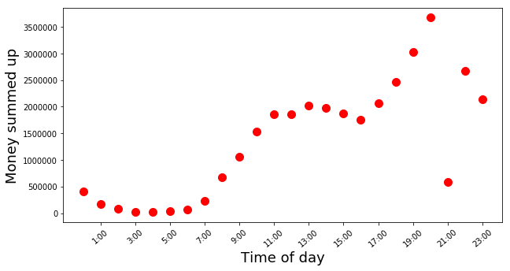

```python
# Stworzenie wykresu
plt.rcParams['figure.figsize'] = [10, 5]
plt.plot_date(money_flow_by_hour.date, money_flow_by_hour.price, markersize=10, color='red')
plt.xticks([datetime(2016, 4, 3, x, 0) for x in np.arange(1, 24, 2)],
           labels=concat(np.arange(1, 24, 2), [":00"] * 12))
plt.xlabel("Time of day", fontsize=18)
plt.ylabel("Money summed up", fontsize=18)
plt.xticks(rotation=40)

plt.show()
```

Generalnie takich wyników można było się spodziewać - ledwie zauważalnych zakupów w nocy, następnie wzwyżu w godzinach kiedy przeważająca większość społeczeństwa wstaje, jednak nie aż tak dużego jak ten kiedy wszyscy wracają z pracy, szkoły, uczelni. Ciężko wytłumaczalny jest jedynie spadek o godzinie 21. Spodziewać można było się raczej utworzenia naturalnego połączenia między pozostałymi obserwacjami.

Pakiet *lens* służy do eskploracji i analizy danych. Należy przekazać mu obiekt typu *pandas.DataFrame*, a on w środku postara się podsumować wiele zmiennych, zbadać zależności miedzy nimi, przygotować kilka ciekawych wykresów. Przy użyciu dwóch obiektów: *Summary* oraz *Explorer* można dokonać wiele ciekawych obserwacji, jednak dane z serwisu *Allegro* wydają się niewzruszone na funkcje które pakiet jest w stanie nam zaoferować.

```python
# help(lens)
```

```python
# Mały processing danych na rzecz późniejszych wyników
for i in [1, 2, 4, 5]:
    allegro.iloc[:, i] = pd.Categorical(allegro.iloc[:, i]).rename_categories([0, 1])
    allegro.iloc[:, i] = pd.Series(allegro.iloc[:, i], dtype='float64')

# Summary - podstawowy obiekt pakietu lens. Z niego można dalej utworzyć obiekt Explorer
# Warto uzbroić się w cierpliwość, funkcja może zająć do kilku minut
summary = lens.summarise(allegro.iloc[:, range(1, 7)])
explorer = lens.explore(summary)
```

```python
summary.columns
```

```
['pay_option_on_delivery',
 'pay_option_transfer',
 'price',
 'it_is_allegro_standard',
 'it_is_brand_zone',
 'main_category_eng']
```

```python
summary.summary('price')
```

```
{'name': 'price',
 'desc': 'numeric',
 'nulls': 0,
 'notnulls': 420020,
 'unique': 9722,
 'dtype': 'float64'}
```

```python
summary.details('price')
```

```
{'name': 'price',
 'desc': 'numeric',
 'min': 0.0,
 'max': 119000.0,
 'mean': 76.81135036404265,
 'median': 24.99,
 'std': 390.32627143155236,
 'sum': 32262303.38,
 'iqr': 59.45}
```

```python
explorer.describe()
```

|  | pay_option_on_delivery | pay_option_transfer | price | it_is_allegro_standard | it_is_brand_zone | main_category_eng |
| --- | --- | --- | --- | --- | --- | --- |
| desc | categorical | categorical | numeric | categorical | categorical | categorical |
| dtype | float64 | float64 | float64 | float64 | float64 | object |
| notnulls | 420020 | 420020 | 420020 | 420020 | 420020 | 420020 |
| nulls | 0 | 0 | 0 | 0 | 0 | 0 |
| unique | 2 | 2 | 9722 | 2 | 2 | 27 |

```python
explorer.cdf_plot('price')
print("Najdroższy produkt kupiony za:", max(allegro.price))
```

[interactive chart not shown]

```
Najdroższy produkt kupiony za: 119000.0
```

Ponieważ bardzo odległe obserwacje odstające potrafią sprawić, że wykres będzie nieczytelny (jak powyżej), to zobaczmy jak by to wyglądało, gdybyśmy badali produkty do 1000 na drugim wykresie:

```python
summary2 = lens.summarise(allegro[allegro.price <= 1000])
explorer2 = lens.explore(summary2)
explorer2.distribution_plot("price")
```

[interactive chart not shown]

Teraz lepiej widać po jakich cenach produkty były najczęściej kupowane. Warto zauważyć na coraz mniejsze *piki* przy okrąglejszych kwotach - może to sugerować, że sprzedający preferują oferować ceny dające się łatwo zaokrąglić. Po przybliżeniu wykresu da się zauważyć, że pik nie jest jedynie przy wartościach dokładnych, na przykład 400, tylko również +-1 wokół.

Poniżej jeszcze jedna funkcjonalność obiektu *Explorer* - macierz korelacji kolumn:

```python
explorer.correlation_plot()
```

[interactive chart not shown]

Jak widać, kolumny są kiepsko skorelowane. Na wykresie dominuje szarość, która oznacza, że ciężko znaleźć jakąkolwiek wspólną cechę między danymi. Poniżej dodaję analogiczną funkcjonalność obiektu *Summary* - *correlation_matrix*. Po zmapowaniu i odpowiednich działaniach widać, że żadna korelacja (oprócz kolumny samej ze sobą) nie wychodzi, co do modułu, ponad 0.5, co potwierdza obserwacje, które już poczyniliśmy wyżej.

```python
def color2(val):
    if val == False:
        color = 'red'
    else:
        color = 'green'
    return 'color: {0}; font-weight: bold; text-align: center'.format(color)

corr = summary.correlation_matrix()
(abs(pd.DataFrame(corr[1].round(3), columns=corr[0], index=corr[0])) > 0.5).style.applymap(color2)
```

|  | pay_option_transfer | pay_option_on_delivery | it_is_allegro_standard | price | it_is_brand_zone |
| --- | --- | --- | --- | --- | --- |
| pay_option_transfer | True | False | False | False | False |
| pay_option_on_delivery | False | True | False | False | False |
| it_is_allegro_standard | False | False | True | False | False |
| price | False | False | False | True | False |
| it_is_brand_zone | False | False | False | False | True |

Warto na sam koniec wspomnieć o innych funkcjonalnościach pakietu *lens* jak na przykład macierzy kontyngencji, czy histogram:

```python
explorer.crosstab("it_is_allegro_standard", "it_is_brand_zone")
```

|  | 0.0 | 1.0 |
| --- | --- | --- |
| 0.0 | 172682 | 240326 |
| 1.0 | 2275 | 4737 |

```
([array([7.4943e+04, 9.0000e+00, 1.0000e+00, 0.0000e+00, 0.0000e+00,
         0.0000e+00, 0.0000e+00, 0.0000e+00, 0.0000e+00, 0.0000e+00]),
  array([7496., 7495., 7495., 7496., 7495., 7495., 7496., 7495., 7495.,
         7496.])],
 array([     0.,  11900.,  23800.,  35700.,  47600.,  59500.,  71400.,
         83300.,  95200., 107100., 119000.]),
 <a list of 2 Lists of Patches objects>)
```

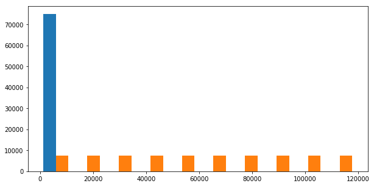

```python
plt.hist(summary.histogram("price"))
```

### Podsumowanie

Pakiet lens okazał się bardzo czytelny. Przejrzysta dokumentacja pozwoliła szybko zaznajomić się z nowymi funkcjonalnościami. Poza zaprezentowanymi istnieje jeszcze kilka pomniejszych. Na sam koniec warto wspomnieć o funkcji *interactive_explore*, która zawiera praktycznie wszystkie powyższe funkcje. Swoją klikalnością zdecydowanie zachęcia użytkowników do korzystania z niej. Wiele wykresów jest podanych na tacy, bez obowiązku poznania dogłębnie pakietu, który swoją drogą nie jest aż taki obszerny.

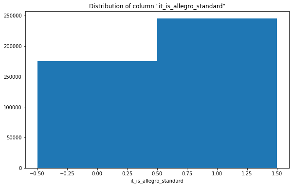

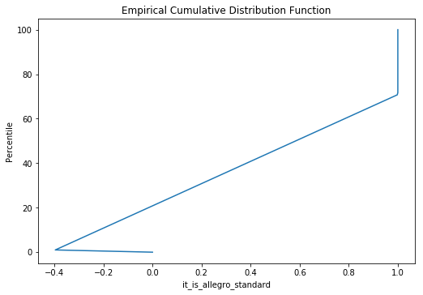

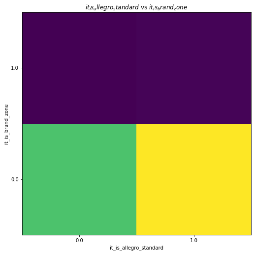

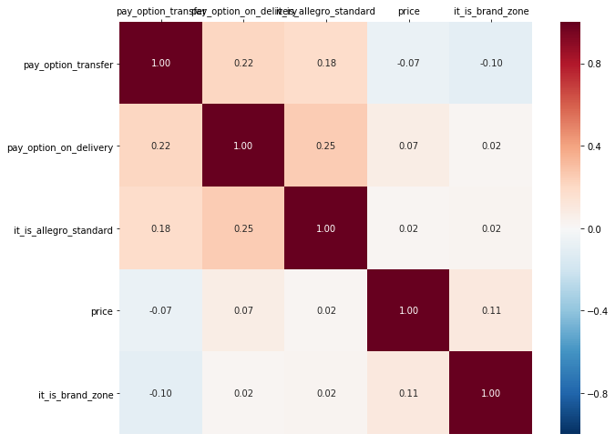

```python
lens.interactive_explore(summary)
```